# 평택성모병원 부적합 검체 관리 (2021)

- 목적 : **부적합 검체 감소를 통한 검사의 질향상**
- 방법 : 각 부서별 부적합 검체 건수 및 사유를 분석, 주요 부적합 검체 발생 부서를 집중 관리하여 **부적합 검체 발생을 최소화하고 모니터링**한다.

### 1. 월별 부적합 검체수

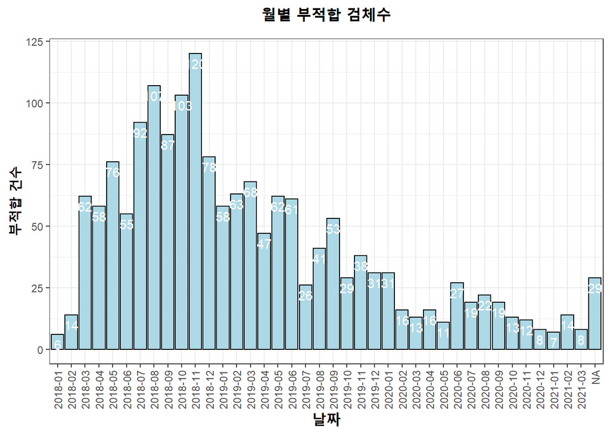

| 날짜 | 건수 |
| --- | --- |
| 2018-01 | 6 |
| 2018-02 | 14 |
| 2018-03 | 62 |
| 2018-04 | 58 |
| 2018-05 | 76 |
| 2018-06 | 55 |
| 2018-07 | 92 |
| 2018-08 | 107 |
| 2018-09 | 87 |
| 2018-10 | 103 |
| 2018-11 | 120 |
| 2018-12 | 78 |
| 2019-01 | 58 |
| 2019-02 | 63 |
| 2019-03 | 68 |
| 2019-04 | 47 |
| 2019-05 | 62 |
| 2019-06 | 61 |
| 2019-07 | 26 |
| 2019-08 | 41 |
| 2019-09 | 53 |
| 2019-10 | 29 |
| 2019-11 | 38 |
| 2019-12 | 31 |
| 2020-01 | 31 |
| 2020-02 | 16 |
| 2020-03 | 13 |
| 2020-04 | 16 |
| 2020-05 | 11 |
| 2020-06 | 27 |
| 2020-07 | 19 |
| 2020-08 | 22 |
| 2020-09 | 19 |
| 2020-10 | 13 |
| 2020-11 | 12 |
| 2020-12 | 8 |
| 2021-01 | 7 |
| 2021-02 | 14 |
| 2021-03 | 8 |
| NA | 29 |

### 2.부서별 부적합 검체수

- 가장 많은 부적합 검체가 발생하는 부서는 **ER, ICU, 각 병동, 검진센터**였으며, 이들 부서가 **전체 부적합 검체의 80% 이상을 차지**함
- 모든 부서를 관리하는 것보다 **ER, ICU, 각 병동, 검진센터를 집중 관리**하는 것이 중요 (**특히 ER**)

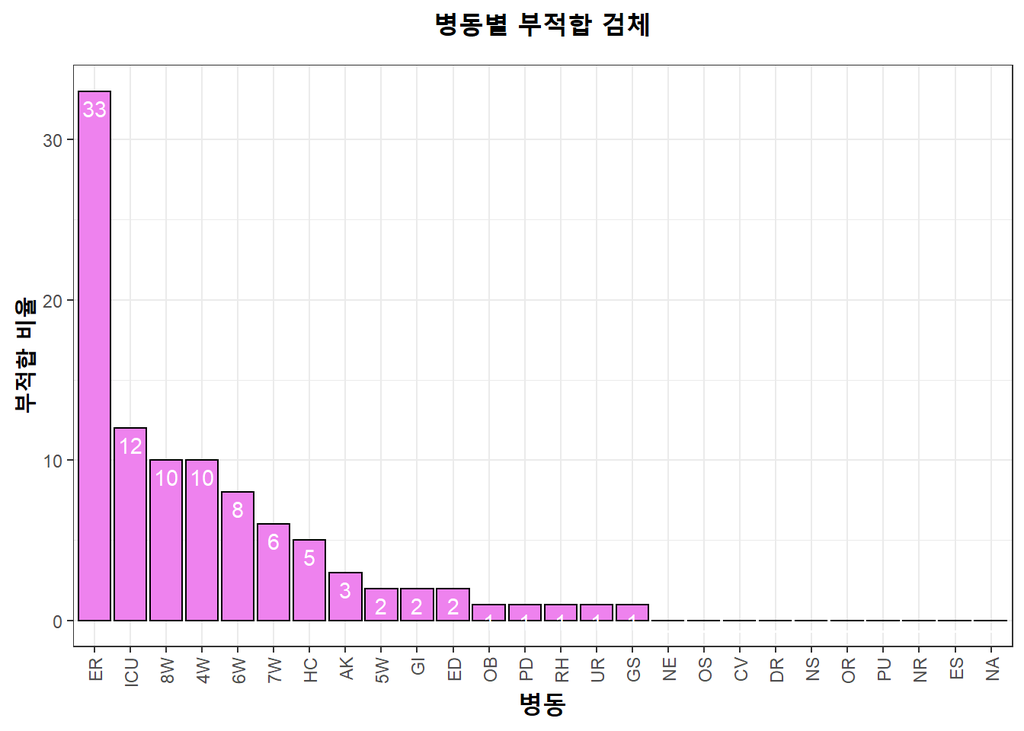

| 과병동 | 건수 | 비율 |
| --- | --- | --- |
| ER | 563 | 33 |
| ICU | 207 | 12 |
| 8W | 175 | 10 |
| 4W | 172 | 10 |
| 6W | 136 | 8 |
| 7W | 96 | 6 |
| HC | 79 | 5 |
| AK | 51 | 3 |
| 5W | 37 | 2 |
| GI | 33 | 2 |
| ED | 28 | 2 |
| OB | 25 | 1 |
| PD | 16 | 1 |
| RH | 14 | 1 |
| UR | 14 | 1 |
| GS | 13 | 1 |
| NE | 7 | 0 |
| OS | 7 | 0 |
| CV | 5 | 0 |
| DR | 5 | 0 |
| NS | 5 | 0 |
| OR | 4 | 0 |
| PU | 4 | 0 |
| NR | 2 | 0 |
| ES | 1 | 0 |
| NA | 1 | 0 |

### 3. 문제점별 부적합 검체수

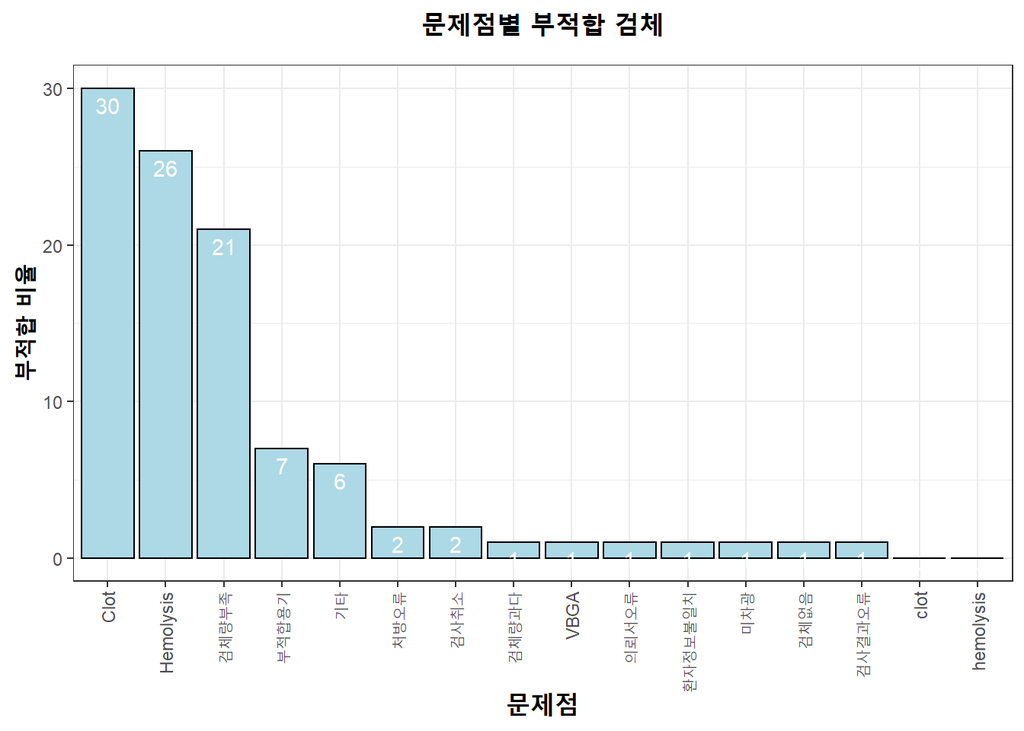

| 문제점 | 비율 |
| --- | --- |
| Clot | 30 |
| Hemolysis | 26 |
| 검체량부족 | 21 |
| 부적합용기 | 7 |
| 기타 | 6 |
| 처방오류 | 2 |
| 검사취소 | 2 |
| 검체량과다 | 1 |
| VBGA | 1 |
| 의뢰서오류 | 1 |
| 환자정보불일치 | 1 |
| 미차광 | 1 |
| 검체없음 | 1 |
| 검사결과오류 | 1 |
| clot | 0 |
| hemolysis | 0 |

### 4. 집중관리 부서별 부적합 검체수

- 집중 관리 대상인, ER, ICU, 각 병동, 검진센터만 따로 데이터를 보아 부적합 검체수를 집계함.
- 집중 관리 시행 후 부적합 검체 발생 건수가 감소하는지 모니터링

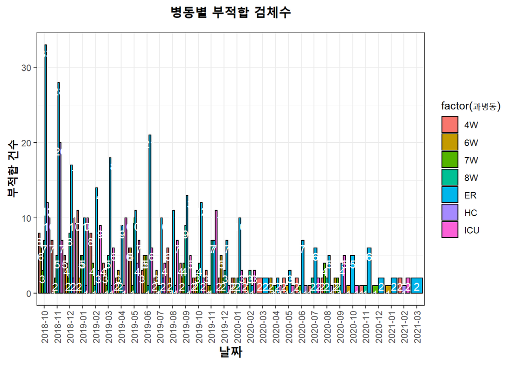

### 5. 날짜별 부적합 검체수

- 주요 관리 부서 대상 날짜별 부적합 검체수를 모니터링

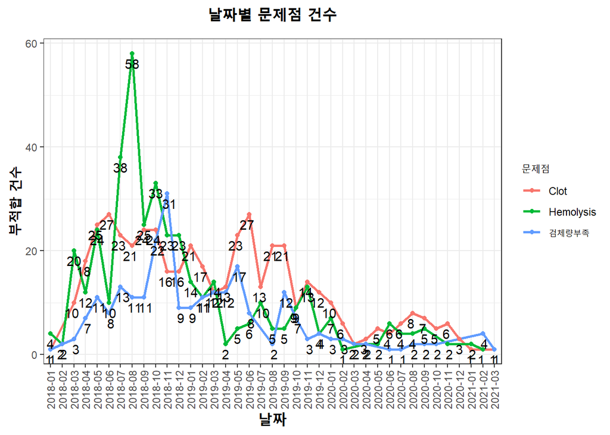

### 6. 부적합 검체수 증감 통계

- 주요 관리 부서의 주요 관리 문제의 **전년 동월대비 부적합 검체수 증감을 건수와 비율로 확인**
- 부적합 검체 관리가 잘 될 경우, 건수와 비율은 마이너스값을 보일 것으로 예상됨

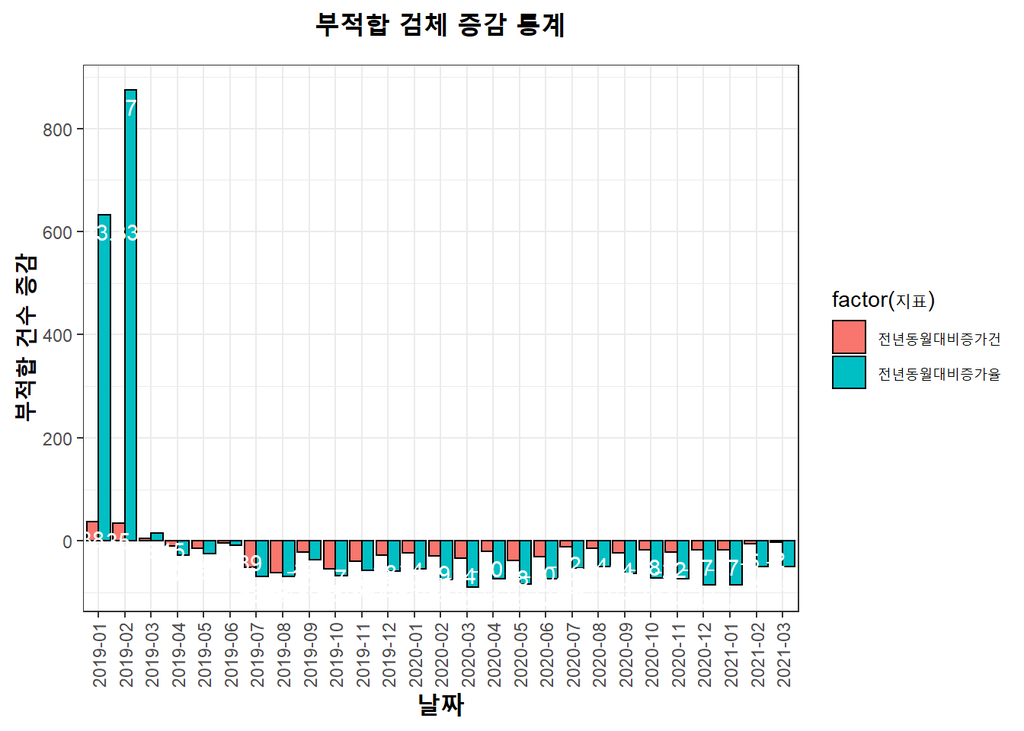

| 날짜 | 지표 | 증감 |
| --- | --- | --- |
| 2019-01 | 전년동월대비증가건 | 38.00 |
| 2019-02 | 전년동월대비증가건 | 35.00 |
| 2019-03 | 전년동월대비증가건 | 5.00 |
| 2019-04 | 전년동월대비증가건 | -10.00 |
| 2019-05 | 전년동월대비증가건 | -15.00 |
| 2019-06 | 전년동월대비증가건 | -4.00 |
| 2019-07 | 전년동월대비증가건 | -51.00 |
| 2019-08 | 전년동월대비증가건 | -62.00 |
| 2019-09 | 전년동월대비증가건 | -22.00 |
| 2019-10 | 전년동월대비증가건 | -54.00 |
| 2019-11 | 전년동월대비증가건 | -40.00 |
| 2019-12 | 전년동월대비증가건 | -28.00 |
| 2020-01 | 전년동월대비증가건 | -24.00 |
| 2020-02 | 전년동월대비증가건 | -29.00 |
| 2020-03 | 전년동월대비증가건 | -34.00 |
| 2020-04 | 전년동월대비증가건 | -20.00 |
| 2020-05 | 전년동월대비증가건 | -38.00 |
| 2020-06 | 전년동월대비증가건 | -30.00 |
| 2020-07 | 전년동월대비증가건 | -12.00 |
| 2020-08 | 전년동월대비증가건 | -14.00 |
| 2020-09 | 전년동월대비증가건 | -24.00 |
| 2020-10 | 전년동월대비증가건 | -18.00 |
| 2020-11 | 전년동월대비증가건 | -22.00 |
| 2020-12 | 전년동월대비증가건 | -17.00 |
| 2021-01 | 전년동월대비증가건 | -17.00 |
| 2021-02 | 전년동월대비증가건 | -5.00 |
| 2021-03 | 전년동월대비증가건 | -2.00 |
| 2019-01 | 전년동월대비증가율 | 633.33 |
| 2019-02 | 전년동월대비증가율 | 875.00 |
| 2019-03 | 전년동월대비증가율 | 15.15 |
| 2019-04 | 전년동월대비증가율 | -27.03 |
| 2019-05 | 전년동월대비증가율 | -25.00 |
| 2019-06 | 전년동월대비증가율 | -8.89 |
| 2019-07 | 전년동월대비증가율 | -68.92 |
| 2019-08 | 전년동월대비증가율 | -68.89 |
| 2019-09 | 전년동월대비증가율 | -36.67 |
| 2019-10 | 전년동월대비증가율 | -68.35 |
| 2019-11 | 전년동월대비증가율 | -57.14 |
| 2019-12 | 전년동월대비증가율 | -58.33 |
| 2020-01 | 전년동월대비증가율 | -54.55 |
| 2020-02 | 전년동월대비증가율 | -74.36 |
| 2020-03 | 전년동월대비증가율 | -89.47 |
| 2020-04 | 전년동월대비증가율 | -74.07 |
| 2020-05 | 전년동월대비증가율 | -84.44 |
| 2020-06 | 전년동월대비증가율 | -73.17 |
| 2020-07 | 전년동월대비증가율 | -52.17 |
| 2020-08 | 전년동월대비증가율 | -50.00 |
| 2020-09 | 전년동월대비증가율 | -63.16 |
| 2020-10 | 전년동월대비증가율 | -72.00 |
| 2020-11 | 전년동월대비증가율 | -73.33 |
| 2020-12 | 전년동월대비증가율 | -85.00 |
| 2021-01 | 전년동월대비증가율 | -85.00 |
| 2021-02 | 전년동월대비증가율 | -50.00 |
| 2021-03 | 전년동월대비증가율 | -50.00 |

### 7. 2021년 부적합 검체 관리 결과

- 부적합 검체 발생 건수 전월, 전년동월 대비 감소 추세로 긍정적인 결과 확인
- 부적합 검체 주요 발생 부서인 ER에서 부적합 검체수 대폭 감소
- 부적합 검체 관리 결과 전년 대비 부적합 검체 발생 건수 지속적으로 감소 확인됨
- 향후 지속적 모니터링